# Comprehensive Output Analysis Tools

Chengxue Li

Last update: 2024-12-02

This vignette introduces how to use `plot_mse_output()` function to summarize and visualize the results of management strategy evaluation. `plot_mse_output()` function is capable of summarizing management strategy evaluation results from one realization and from n realizations, when using parallel computing (see Example 5 for more details)). The results can be presented in line plot, scatter plot, box plot, and radar chart for users to better compare performance among different management strategies. Please use ?plot_mse_output to see more details. Below are one example about plotting results from one realization and one example about plotting results from n realizations.

### 1. Results from one realization

Suppose you only run a management strategy evaluation for one realization (e.g. Example 4):

```r
library(wham)
library(whamMSE)

main.dir = here::here() # Or the path you want to save the results.

# Remember in Example 4 we have 3 EMs saved in a list called "mods".
mods <- readRDS("Mods.rds") # path where you saved the results from Ex4.

plot_mse_output(mods = mods, main.dir = getwd(), dpi = 150,
                use.n.years = 10, # The last 10 years will be used for comparison of long-term performance
                base.mod = 1, # specify which model is used as a base model
                short.term = NULL, # if NULL, results of first 2 years will be used for comparison of short-term performance
                out.type = "png") # Options: png, pdf, html
```

#### 1.1 Spawning stock biomass (SSB) over time, stocks-specific SSB and global SSB are plotted below:

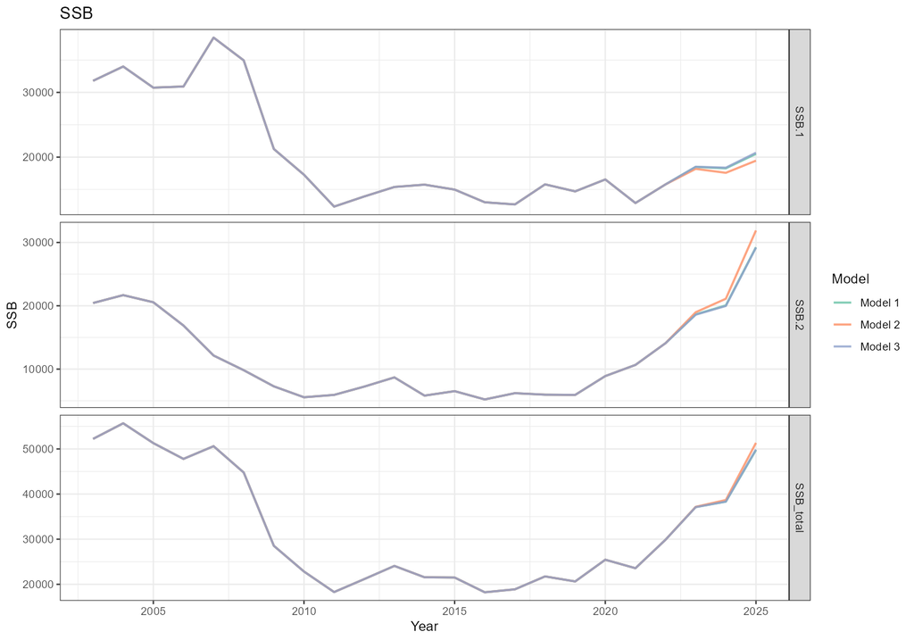

Figure 1

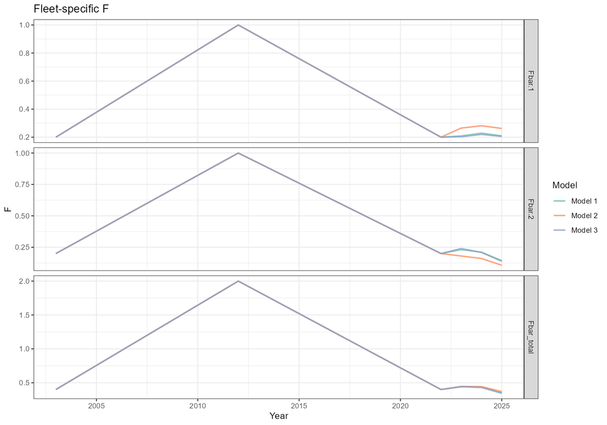

Figure 2

#### 1.3 Catch over time, region-specific catch and total catch are plotted below:

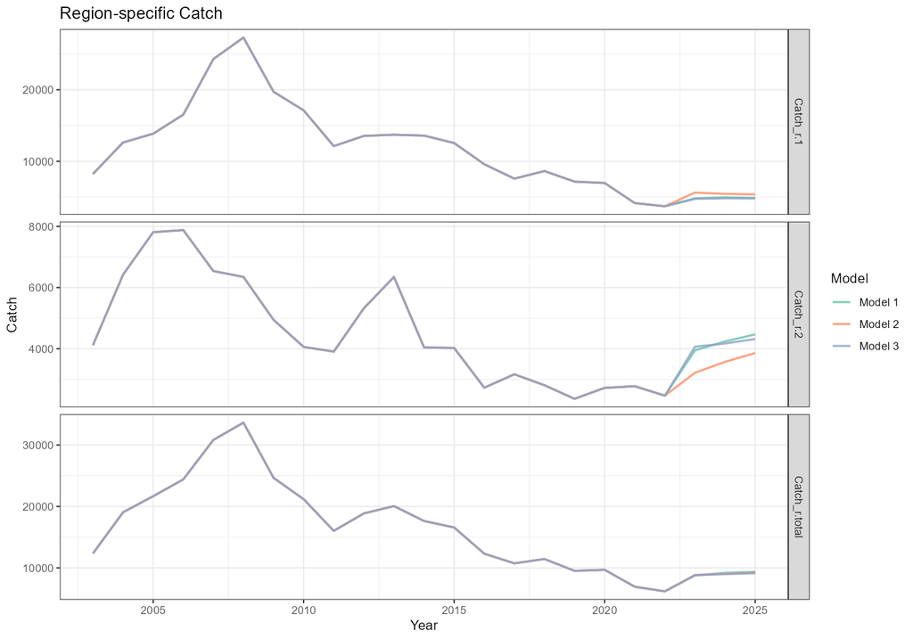

Figure 3

#### 1.4 Catch over time, stock-specific catch and total catch are plotted below:

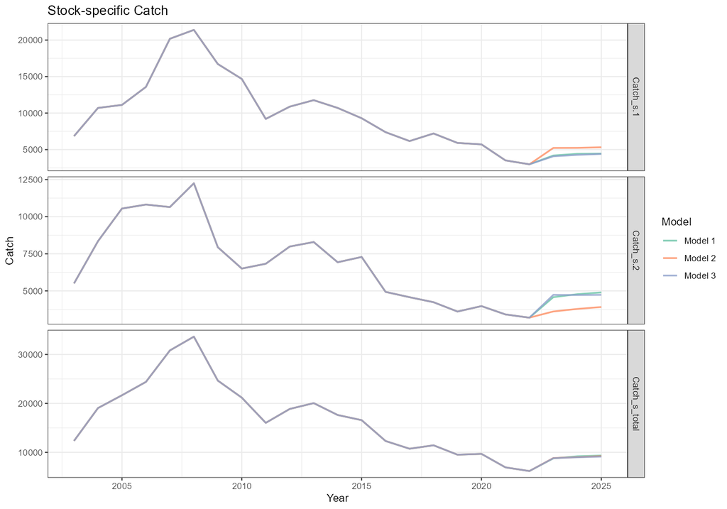

Figure 4

#### 1.5 Performance summarized over the last 10 years are summarized below:

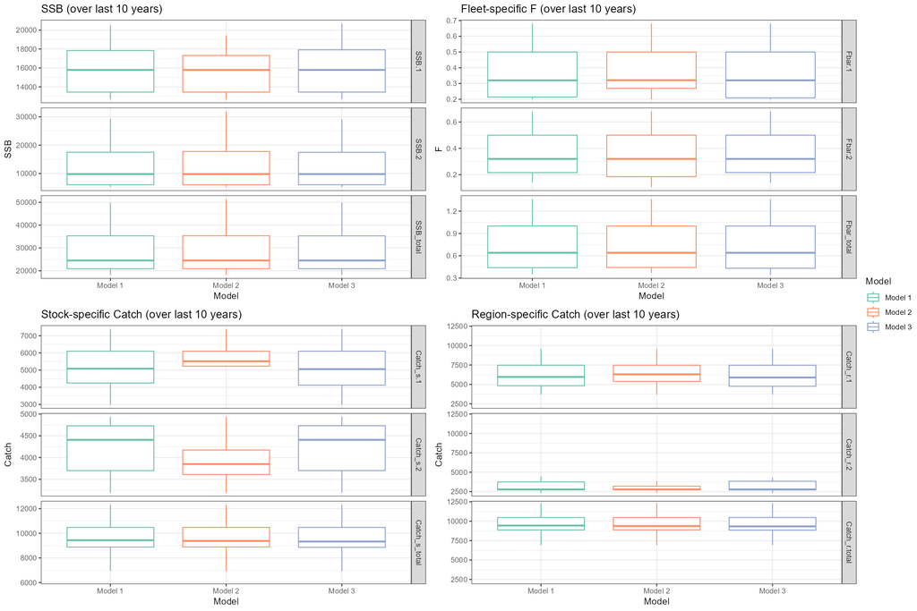

Figure 5

### 2. Results from n realizations

```r
mods = list()

for (nsim in 1:10) {
  file.names <- file.path(sub.dir,paste0("Mod",1:6,sprintf("_%03d.RDS",nsim))) # path where you saved the results from Ex5.
  mods[[nsim]] <- lapply(file.names, readRDS)
}

plot_mse_output(mods = mods, main.dir = getwd(), dpi = 150,
                use.n.years = 10, # The last 10 years will be used for comparison of long-term performance
                base.mod = 6, # "correct" EM that can be used as a reference
                short.term = NULL, # if NULL, results of first 2 years will be used for comparison of short-term performance
                out.type = "html") # Options: png, pdf, html
```

#### 2.1 Performance summarized over the last 10 years across EMs over n realizations:

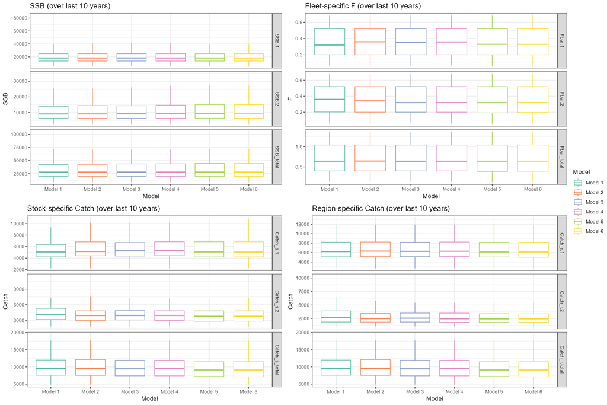

Figure 1

#### 2.2 Relative difference in performance between correct EMs and mis-specified EMs:

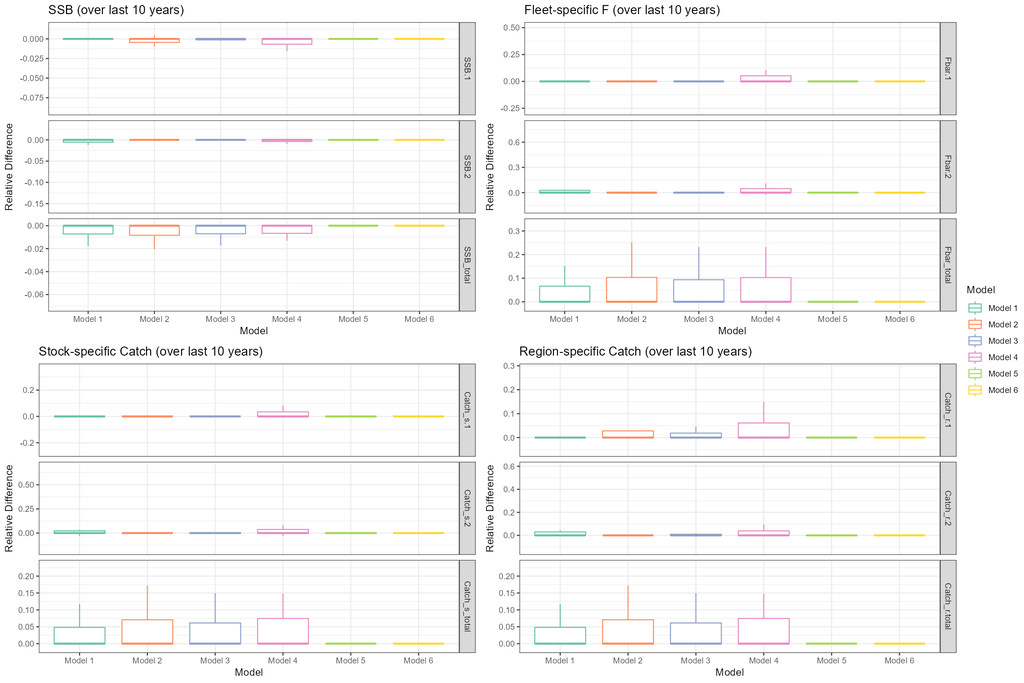

Figure 2

#### 2.3 Holistic view of performance of different EMs:

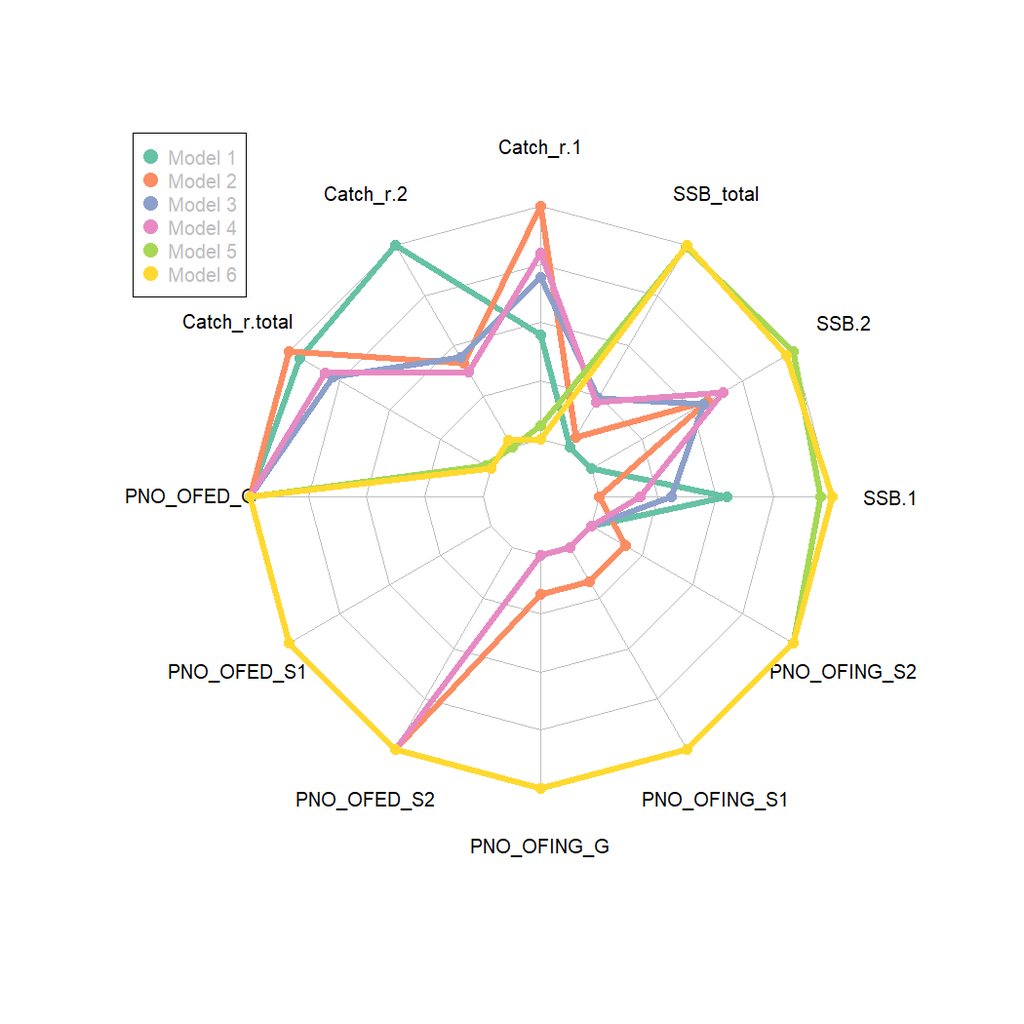

Figure 3

#### 2.4 Annual population status in the last 10 years across EMs and n realizations:

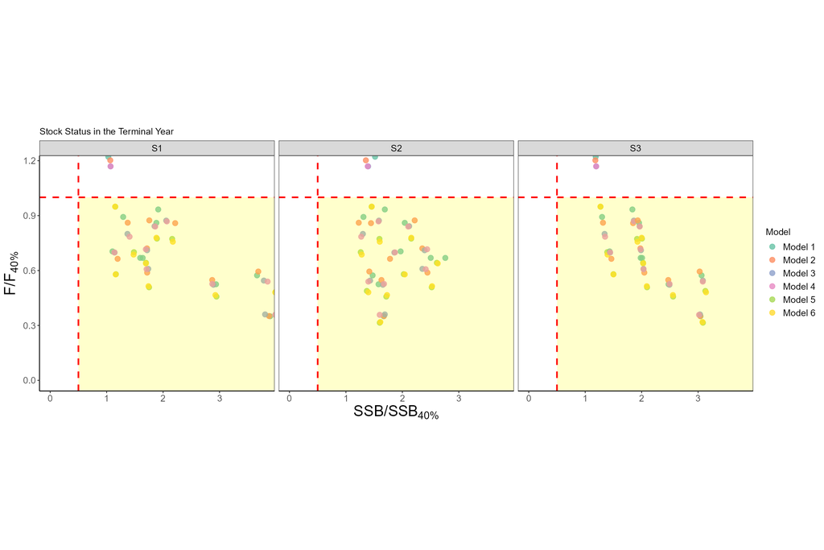

Figure 4

#### 2.5 Short-term performance (over the first 2 years) across EMs and n realizations:

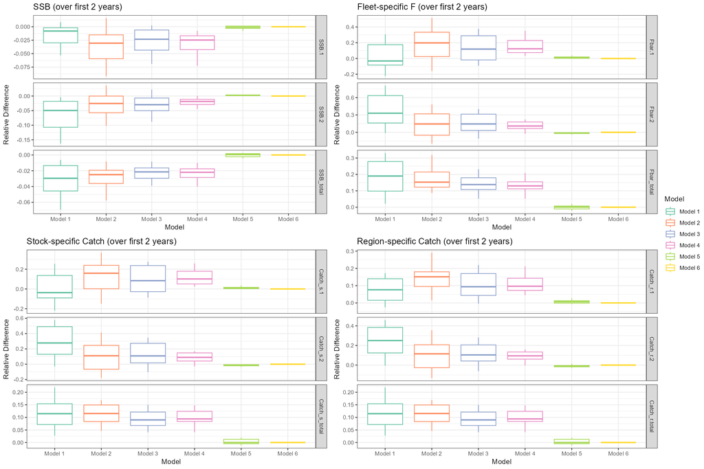

Figure 5

#### 2.6 Estimates of mean recruitment, variances of NAA deviations, and AIC:

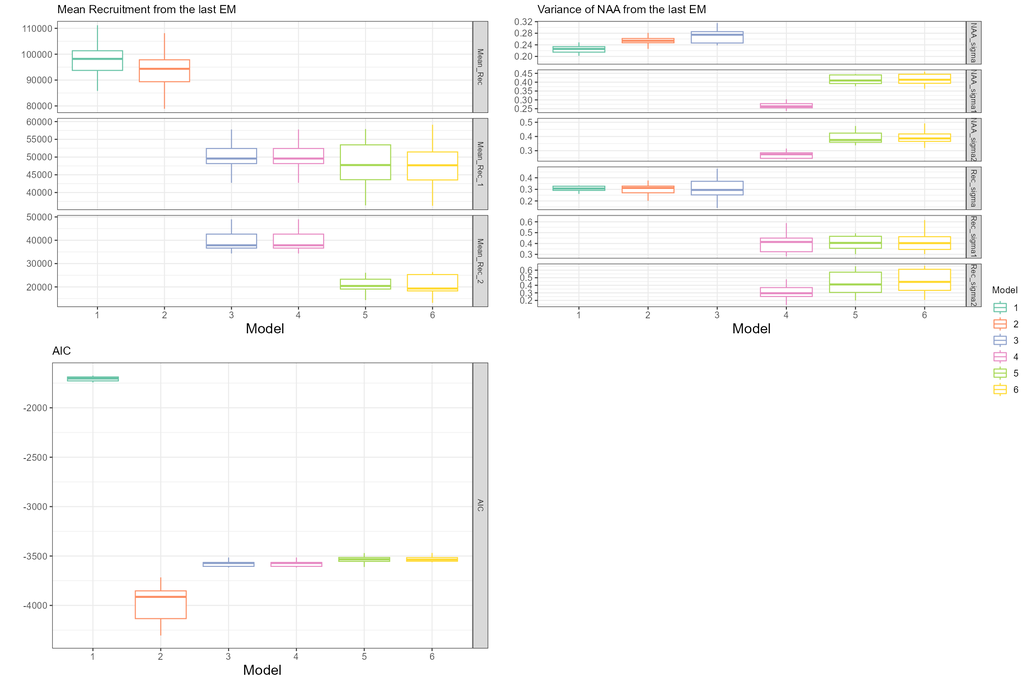

Figure 6

#### 2.7 For full report of terminal-year assessment model, please use:

```r
plot_wham_output(mods[[1]][[6]]$em_full[[1]], out.type = "html") # plot EM6 from the 1st realization
```

#### 2.8 Check model convergence in every assessment model in the feedback period

```r
mods[[1]][[6]]$converge_list # EM6 from the 1st realization
# Here 2 indicates the assessment model is converged (optimization complete = 1 and Hessian is invertible = 1).
```

#### 2.9 Check catch advice generated from every assessment model in the feedback period

```r
mods[[1]][[6]]$catch_advice # catch advice generated from EM6 from the first realization
```